# Text mining, sentiment analysis, and visualization in the Lord of the Rings

Christian Reinholdt

18 maj, 2025

### Credits:

This sentiment analysis is inspired by Allison Horst’s Advanced Statistics and Data Analysis.

### Get the LOTR text:

```r
lotr_path <- here("data/lotr.pdf")
lotr_text <- pdf_text(lotr_path)
```

Some things to notice:

- How cool to extract text out of a PDF! Do you think it will work with any PDF?
- Each row is a page of the PDF (i.e., this is a vector of strings, one for each page)
- The pdf_text() function only sees text that is “selectable”

Example: Just want to get text from a single page (e.g. Page 59)?

```r
lotr_p59 <- lotr_text[59]
lotr_p59
```

```
## [1] "                       A LONG-EXPECTED PARTY                              35\n\n    ‘Indeed it would take away the only point I ever saw in the affair,’\nsaid Gandalf.\n    ‘Very well,’ said Bilbo, ‘it goes to Frodo with all the rest.’ He drew\na deep breath. ‘And now I really must be starti…
```

See how that compares to the text in the PDF on Page 59. What has pdftools added and where? Well, first off, it is what we read as p. 35 - but it is of course p. 59 in the pdf. But it is only p. 35 of the actual text, coming after various introductions. pdftools has also added before every new line.

From Jessica and Casey’s text mining workshop: “pdf_text() returns a vector of strings, one for each page of the pdf. So we can mess with it in tidyverse style, let’s turn it into a dataframe, and keep track of the pages. Then we can use stringr::str_split() to break the pages up into individual lines. Each line of the pdf is concluded with a backslash-n, so split on this. We will also add a line number in addition to the page number.”

### Some wrangling:

- Split up pages into separate lines (separated by `\n`) using `stringr::str_split()`
- Unnest into regular columns using `tidyr::unnest()`
- Remove leading/trailing white space with `stringr::str_trim()`

```r
lotr_df <- data.frame(lotr_text) %>%
  mutate(text_full = str_split(lotr_text, pattern = '\n')) %>%
  unnest(text_full) %>%
  mutate(text_full = str_trim(text_full))

# More information: https://cran.r-project.org/web/packages/stringr/vignettes/regular-expressions.html
```

Now each line, on each page, is its own row, with extra starting & trailing spaces removed.

### Get the tokens (individual words) in tidy format

Use `tidytext::unnest_tokens()` (which pulls from the `tokenizer`) package, to split columns into tokens. We are interested in *words*, so that’s the token we’ll use:

```r
lotr_tokens <- lotr_df %>%
  unnest_tokens(word, text_full)

# See how this differs from `lotr_df`
# Each word has its own row!
```

Let’s count the words!

```r
lotr_wc <- lotr_tokens %>%
  count(word) %>%
  arrange(-n)
lotr_wc
```

```
## # A tibble: 16,965 × 2
##    word      n
##    <chr> <int>
##  1 the   36115
##  2 and   22286
##  3 of    17784
##  4 to    11201
##  5 a     10042
##  6 in     8991
##  7 he     8470
##  8 it     6822
##  9 that   6727
## 10 was    6581
## # ℹ 16,955 more rows
```

OK…so we notice that a whole bunch of things show up frequently that we might not be interested in (“a”, “the”, “and”, etc.). These are called *stop words*. Let’s remove them.

### Remove stop words:

See `?stop_words` and `View(stop_words)`to look at documentation for stop words lexicons.

We will *remove* stop words using `tidyr::anti_join()`:

```r
lotr_stop <- lotr_tokens %>%
  anti_join(stop_words) %>%
  select(-lotr_text)
```

Now check the counts again:

```r
lotr_swc <- lotr_stop %>%
  count(word) %>%
  arrange(-n)
```

What if we want to get rid of all the numbers (non-text) in `lotr_stop`?

```r
# This code will filter out numbers by asking:
# If you convert to as.numeric, is it NA (meaning those words)?
# If it IS NA (is.na), then keep it (so all words are kept)
# Anything that is converted to a number is removed

lotr_no_numeric <- lotr_stop %>%
  filter(is.na(as.numeric(word)))
```

### A word cloud of LOTR words (non-numeric)

See more: https://cran.r-project.org/web/packages/ggwordcloud/vignettes/ggwordcloud.html

```r
# There are almost 2000 unique words in the IPCC - well, there are 14,856 in LOTR.
length(unique(lotr_no_numeric$word))
```

```
## [1] 14856
```

```r
# We probably don't want to include them all in a word cloud. Let's filter to only include the top 100 most frequent?
lotr_top100 <- lotr_no_numeric %>%
  count(word) %>%
  arrange(-n) %>%
  head(100)
lotr_top100
```

```
## # A tibble: 100 × 2
##    word        n
##    <chr>   <int>
##  1 frodo    1923
##  2 sam      1238
##  3 gandalf  1190
##  4 lord     1056
##  5 dark      863
##  6 time      814
##  7 aragorn   804
##  8 rings     696
##  9 pippin    662
## 10 looked    637
## # ℹ 90 more rows
```

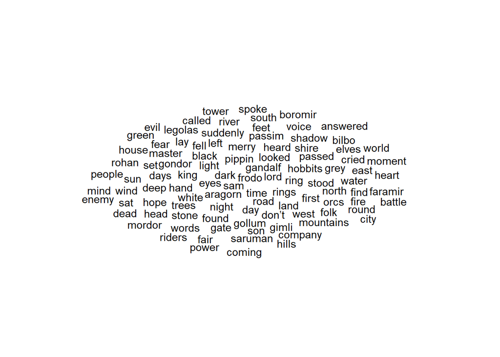

```r
lotr_cloud <- ggplot(data = lotr_top100, aes(label = word)) +
  geom_text_wordcloud() +
  theme_minimal()

lotr_cloud
```

That’s underwhelming. Let’s customize it a bit:

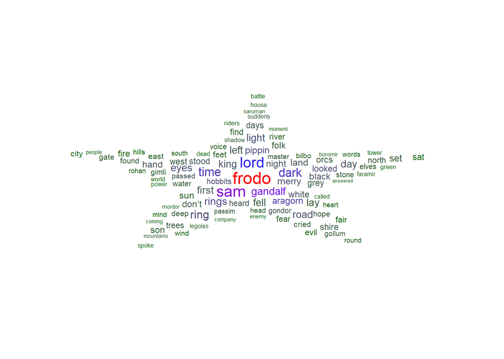

```r
ggplot(data = lotr_top100, aes(label = word, size = n)) +
  geom_text_wordcloud_area(aes(color = n), shape = "star") +
  scale_size_area(max_size = 12) +
  scale_color_gradientn(colors = c("darkgreen","blue","red")) +
  theme_minimal()
```

Cool! And you can facet wrap (for different reports, for example) and update other aesthetics. See more here: https://cran.r-project.org/web/packages/ggwordcloud/vignettes/ggwordcloud.html

### Sentiment analysis

First, check out the ‘sentiments’ lexicon. From Julia Silge and David Robinson (https://www.tidytextmining.com/sentiment.html):

“The three general-purpose lexicons are

- AFINN from Finn Årup Nielsen,
- bing from Bing Liu and collaborators, and
- nrc from Saif Mohammad and Peter Turney

All three of these lexicons are based on unigrams, i.e., single words. These lexicons contain many English words and the words are assigned scores for positiv1e/negative sentiment, and also possibly emotions like joy, anger, sadness, and so forth. The AFINN lexicon assigns words with a score that runs between -5 and 5, with negative scores indicating negative sentiment and positive scores indicating positive sentiment. The bing lexicon categorizes words in a binary fashion into positive and negative categories. The nrc lexicon categorizes words in a binary fashion (“yes”/“no”) into categories of positive, negative, anger, anticipation, disgust, fear, joy, sadness, surprise, and trust. All of this information is tabulated in the sentiments dataset, and tidytext provides a function get_sentiments() to get specific sentiment lexicons without the columns that are not used in that lexicon.”

Let’s explore the sentiment lexicons. “bing” is included, other lexicons (“afinn”, “nrc”, “loughran”) you’ll be prompted to download.

**WARNING:** These collections include very offensive words. I urge you to not look at them in class.

“afinn”: Words ranked from -5 (very negative) to +5 (very positive)

```r
get_sentiments(lexicon = "afinn")
```

```
## # A tibble: 2,477 × 2
##    word       value
##    <chr>      <dbl>
##  1 abandon       -2
##  2 abandoned     -2
##  3 abandons      -2
##  4 abducted      -2
##  5 abduction     -2
##  6 abductions    -2
##  7 abhor         -3
##  8 abhorred      -3
##  9 abhorrent     -3
## 10 abhors        -3
## # ℹ 2,467 more rows
```

```r
# You should be prompted to install lexicon - choose yes!


# Let's look at the pretty positive words:
afinn_pos <- get_sentiments("afinn") %>%
  filter(value %in% c(3,4,5))

# Do not look at negative words in class.
afinn_pos
```

```
## # A tibble: 222 × 2
##    word         value
##    <chr>        <dbl>
##  1 admire           3
##  2 admired          3
##  3 admires          3
##  4 admiring         3
##  5 adorable         3
##  6 adore            3
##  7 adored           3
##  8 adores           3
##  9 affection        3
## 10 affectionate     3
## # ℹ 212 more rows
```

bing: binary, “positive” or “negative”

```r
get_sentiments(lexicon = "bing")
```

```
## # A tibble: 6,786 × 2
##    word        sentiment
##    <chr>       <chr>
##  1 2-faces     negative
##  2 abnormal    negative
##  3 abolish     negative
##  4 abominable  negative
##  5 abominably  negative
##  6 abominate   negative
##  7 abomination negative
##  8 abort       negative
##  9 aborted     negative
## 10 aborts      negative
## # ℹ 6,776 more rows
```

```r
# You should be prompted to install lexicon - choose yes!
```

### Sentiment analysis with afinn:

First, bind words in `lotr_stop` to `afinn` lexicon:

```r
lotr_afinn <- lotr_stop %>%
  inner_join(get_sentiments("afinn"))
lotr_afinn
```

```
## # A tibble: 20,652 × 2
##    word       value
##    <chr>      <dbl>
##  1 doomed        -2
##  2 die           -3
##  3 darkness      -1
##  4 matters        1
##  5 cut           -1
##  6 conspiracy    -3
##  7 grey          -1
##  8 battle        -1
##  9 doom          -2
## 10 grey          -1
## # ℹ 20,642 more rows
```

Let’s find some counts (by sentiment ranking):

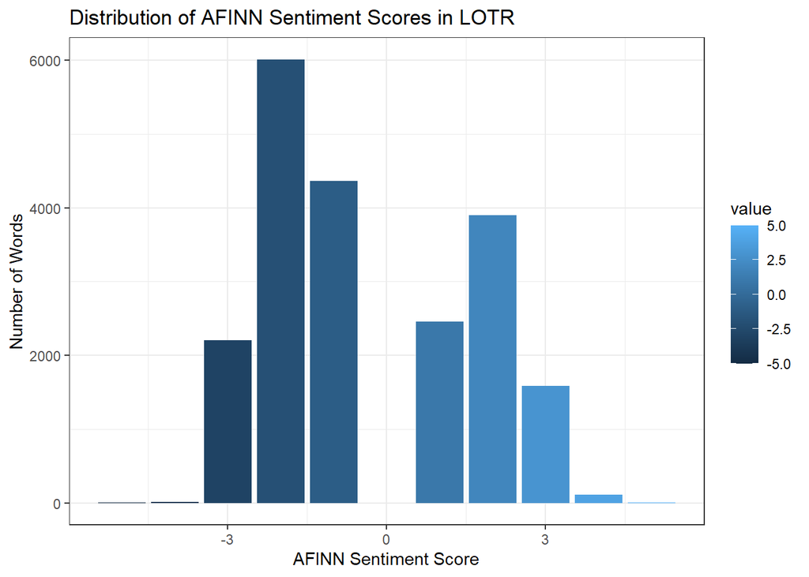

```r
lotr_afinn_hist <- lotr_afinn %>%
  count(value)

# Plot them:
ggplot(data = lotr_afinn_hist, aes(x = value, y = n)) +
  geom_col(aes(fill = value)) +
  theme_bw() +
  labs(
    title = "Distribution of AFINN Sentiment Scores in LOTR",
    x = "AFINN Sentiment Score",
    y = "Number of Words"
  )
```

Investigate some of the words in a bit more depth:

```r
# What are these '2' words?
lotr_afinn2 <- lotr_afinn %>%
  filter(value == 2)
```

```r
# Check the unique 2-score words:
unique(lotr_afinn2$word)
```

```
##   [1] "appreciation"  "ability"       "integrity"     "recommend"
##   [5] "growth"        "true"          "astonished"    "romance"
##   [9] "appreciated"   "survived"      "accomplished"  "opportunities"
##  [13] "enjoy"         "chances"       "improve"       "opportunity"
##  [17] "carefully"     "noble"         "importance"    "surviving"
##  [21] "hope"          "desired"       "inspiration"   "encouraged"
##  [25] "approved"      "inspired"      "freedom"       "adventure"
##  [29] "remarkable"    "peace"         "swiftly"       "stout"
##  [33] "fond"          "friendly"      "adventurous"   "strong"
##  [37] "rich"          "ease"          "top"           "comfortable"
##  [41] "improved"      "care"          "fair"          "sweet"
##  [45] "generous"      "wealthy"       "treasure"      "gain"
##  [49] "saved"         "chance"        "courage"       "reward"
##  [53] "adventures"    "save"          "gift"          "secured"
##  [57] "hopes"         "irresponsible" "lively"        "kinder"
```

[output cut: 40 more lines]

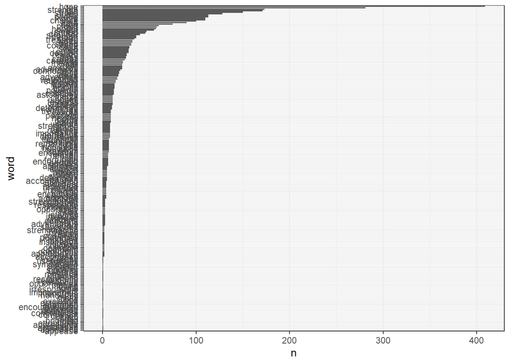

```r
# Count & plot them
lotr_afinn2_n <- lotr_afinn2 %>%
  count(word, sort = TRUE) %>%
  mutate(word = fct_reorder(factor(word), n))


ggplot(data = lotr_afinn2_n, aes(x = word, y = n)) +
  geom_col() +
  coord_flip() +
  theme_bw()
```

We learn something important from this example: Just using a sentiment lexicon to match words will not differentiate between different uses of the word…(ML can start figuring it out with context, but we won’t do that here).

Or we can summarize sentiment for the book:

```r
lotr_summary <- lotr_afinn %>%
  summarize(
    mean_score = mean(value),
    median_score = median(value)
  )
lotr_summary
```

```
## # A tibble: 1 × 2
##   mean_score median_score
##        <dbl>        <dbl>
## 1     -0.370           -1
```

The mean and median indicate *slightly* negative overall sentiments based on the AFINN lexicon.

### NRC Download did not work.